# 2task

```python
%pip install seaborn
```

```python
import numpy as np
import pandas as pd
import random
import matplotlib.pyplot as plt
import matplotlib
import seaborn as sns
import statistics
import torch
from torch.utils.data import random_split
import xgboost as xgb
from sklearn.metrics import accuracy_score
from sklearn.model_selection import train_test_split
from sklearn.tree import DecisionTreeClassifier, DecisionTreeRegressor
from sklearn import tree
from sklearn.preprocessing import StandardScaler
from sklearn.preprocessing import LabelEncoder
from sklearn import metrics
from sklearn.model_selection import cross_val_score, GridSearchCV
import warnings
from imblearn.over_sampling import RandomOverSampler
warnings.filterwarnings('ignore')
```

Загрузка данных и EDA

Данные у меня по продажам домов в Индии

BHK: количество спален, зал, кухня.

Аренда: Аренда домов/квартир/квартир. Наш таргет

Size: Площадь дома/квартиры/квартиры в квадратных футах.

Floor: Дома/квартиры/квартиры, расположенные на каком этаже и общее количество этажей (пример: первый из 2, третий из 5 и т.д.)

Area Type площади: Размер дома/квартиры/квартир, рассчитанный по суперплощади, площади ковра или площади застройки.

City: Город, в котором расположены дома/квартиры/квартиры.

Furnishing Status: Статус мебели домов/квартир/квартир, либо есть мебель, только основное, либо без мебели.

Tenant Preferred: Тип арендатора, которого предпочитает владелец или агент.

Bathroom: Количество ванных комнат.

Point of Contact: С кем вы должны связаться для получения дополнительной информации о домах/квартирах/квартирах.

Я срзу выкинул признак постед он(не звучит особо важно) и ареа локалити(слишком много уникальных значений)

```python
house=pd.read_csv('HouseRent.csv', sep=',')
house=house.drop(["Posted On","Area Locality"], axis=1)
house.head()
```

|  | BHK | Rent | Size | Floor | Area Type | City | Furnishing Status | Tenant Preferred | Bathroom | Point of Contact |
| --- | --- | --- | --- | --- | --- | --- | --- | --- | --- | --- |
| 0 | 2 | 10000 | 1100 | Ground out of 2 | Super Area | Kolkata | Unfurnished | Bachelors/Family | 2 | Contact Owner |
| 1 | 2 | 20000 | 800 | 1 out of 3 | Super Area | Kolkata | Semi-Furnished | Bachelors/Family | 1 | Contact Owner |
| 2 | 2 | 17000 | 1000 | 1 out of 3 | Super Area | Kolkata | Semi-Furnished | Bachelors/Family | 1 | Contact Owner |
| 3 | 2 | 10000 | 800 | 1 out of 2 | Super Area | Kolkata | Unfurnished | Bachelors/Family | 1 | Contact Owner |
| 4 | 2 | 7500 | 850 | 1 out of 2 | Carpet Area | Kolkata | Unfurnished | Bachelors | 1 | Contact Owner |

```python
train,test = train_test_split(house, random_state=1, test_size=0.25)
len(train),len(test)
```

```
(3559, 1187)
```

```python
train
```

|  | BHK | Rent | Size | Floor | Area Type | City | Furnishing Status | Tenant Preferred | Bathroom | Point of Contact |
| --- | --- | --- | --- | --- | --- | --- | --- | --- | --- | --- |
| 1624 | 1 | 11000 | 800 | Ground out of 3 | Super Area | Bangalore | Semi-Furnished | Family | 1 | Contact Owner |
| 456 | 1 | 7000 | 500 | 1 out of 3 | Super Area | Kolkata | Unfurnished | Bachelors/Family | 1 | Contact Owner |
| 3609 | 2 | 9000 | 600 | Ground out of 2 | Super Area | Chennai | Unfurnished | Bachelors/Family | 2 | Contact Owner |
| 2707 | 3 | 65000 | 1600 | Ground out of 4 | Carpet Area | Delhi | Furnished | Bachelors/Family | 2 | Contact Agent |
| 1012 | 3 | 68000 | 1260 | 27 out of 58 | Carpet Area | Mumbai | Unfurnished | Family | 3 | Contact Agent |
| ... | ... | ... | ... | ... | ... | ... | ... | ... | ... | ... |
| 2895 | 1 | 9500 | 450 | 1 out of 3 | Carpet Area | Delhi | Unfurnished | Bachelors/Family | 1 | Contact Owner |
| 2763 | 1 | 19000 | 545 | 2 out of 3 | Super Area | Delhi | Furnished | Bachelors/Family | 1 | Contact Owner |
| 905 | 3 | 50000 | 806 | 2 out of 4 | Super Area | Mumbai | Semi-Furnished | Bachelors/Family | 2 | Contact Owner |
| 3980 | 2 | 20000 | 1600 | 1 out of 2 | Super Area | Hyderabad | Unfurnished | Family | 3 | Contact Owner |
| 235 | 1 | 4500 | 450 | Ground out of 2 | Super Area | Kolkata | Unfurnished | Bachelors/Family | 1 | Contact Owner |

3559 rows × 10 columns

```python
train.info()
```

```
<class 'pandas.core.frame.DataFrame'>
Index: 3559 entries, 1624 to 235
Data columns (total 10 columns):
 #   Column             Non-Null Count  Dtype
---  ------             --------------  -----
 0   BHK                3559 non-null   int64
 1   Rent               3559 non-null   int64
 2   Size               3559 non-null   int64
 3   Floor              3559 non-null   object
 4   Area Type          3559 non-null   object
 5   City               3559 non-null   object
 6   Furnishing Status  3559 non-null   object
 7   Tenant Preferred   3559 non-null   object
 8   Bathroom           3559 non-null   int64
 9   Point of Contact   3559 non-null   object
dtypes: int64(4), object(6)
memory usage: 305.9+ KB
```

Много категориальных переменных, зато нет нулевых значений. Признак floor подозрительно не инт значение

```python
train['Floor'].unique()
```

```
array(['Ground out of 3', '1 out of 3', 'Ground out of 2',
       'Ground out of 4', '27 out of 58', '10 out of 24', '1 out of 2',
       '5 out of 12', '1 out of 4', '2 out of 3', '2 out of 4',
       '1 out of 7', '3 out of 4', 'Ground out of 1', '2 out of 5',
       '4 out of 10', '2 out of 2', '5 out of 7', '1 out of 1',
       '4 out of 7', '8 out of 19', 'Ground out of 5', '10 out of 12',
       '14 out of 18', '4 out of 4', '4 out of 5', '3 out of 5',
       '11 out of 20', '3 out of 6', '1 out of 5', '4 out of 13',
       '4 out of 9', '7 out of 30', '3 out of 3', '7 out of 8',
       '5 out of 5', 'Upper Basement out of 3', '44 out of 75',
       '6 out of 7', '6 out of 16', '15 out of 15', '10 out of 22',
       '10 out of 14', '7 out of 9', '12 out of 13', '6 out of 10',
       '7 out of 19', '3 out of 7', '14 out of 23', '15 out of 31',
       '12 out of 20', '6 out of 8', '10 out of 23', '24 out of 25',
       '5 out of 6', '4 out of 16', '5 out of 20', '4 out of 8',
       '10 out of 16', '15 out of 19', '8 out of 14', '32 out of 59',
       '10 out of 18', '17 out of 60', '2 out of 6', '9 out of 22',
       '7 out of 14', '3 out of 10', '5 out of 17', '17 out of 36',
       '8 out of 20', '8 out of 16', '8 out of 12', '3 out of 21',
       '2 out of 10', '18 out of 26', '6 out of 15', '1 out of 6',
       '46 out of 76', '23 out of 25', '6 out of 18', '2 out of 13',
       '18 out of 23', '12 out of 30', '12 out of 24', '11 out of 23',
       '2 out of 8', '4 out of 6', '15 out of 18', '11 out of 19',
       '5 out of 14', '11 out of 15', '2 out of 14', '18 out of 24',
       '9 out of 18', '1 out of 15', '12 out of 17', '9 out of 17',
       '25 out of 48', '14 out of 22', '2 out of 7', '9 out of 19',
       '7 out of 41', 'Ground out of 7', '9 out of 20', '7 out of 7',
       '15 out of 22', '24 out of 33', '4 out of 14', '10 out of 20',
       '10 out of 31', '5 out of 21', '16 out of 23',
       'Lower Basement out of 18', '12 out of 29', '16 out of 34',
       '21 out of 58', '4 out of 12', '1 out of 8', '18 out of 30',
       '14 out of 14', 'Lower Basement out of 2', '24 out of 55',
       'Ground out of 27', '5 out of 19', '28 out of 30', '3 out of 12',
       '9 out of 12', '8 out of 13', '6 out of 9', '17 out of 31',
       '15 out of 60', '11 out of 26', '3 out of 11', '15 out of 20',
       '41 out of 41', '9 out of 55', '4 out of 26', '13 out of 23',
       '2 out of 16', '33 out of 42', '27 out of 27', '8 out of 10',
       '7 out of 10', '9 out of 14', '19 out of 20', '3 out of 18',
       '7 out of 22', '13 out of 40', '9 out of 29', '1 out of 10',
       '37 out of 51', '16 out of 21', '11 out of 17', '23 out of 23',
```

[output cut: 53 more lines]

```
       'Upper Basement out of 22', '15 out of 25', '15 out of 16',
       '34 out of 46', '1 out of 16', '2 out of 9', '23 out of 40',
       '1 out of 24', '3 out of 14', '6 out of 45', '20 out of 32',
       '25 out of 43', '19 out of 24', '65 out of 76', '13 out of 25',
       '17 out of 43', 'Upper Basement out of 4', '21 out of 33', '1',
       '9 out of 16', '3 out of 15', '65 out of 78', '19 out of 21',
       '12 out of 68', '5 out of 34', '16 out of 38', 'Ground out of 13',
       '5 out of 23', '40 out of 75', '16 out of 27', '11 out of 16',
       '1 out of 14', '16 out of 25', '23 out of 30', '7 out of 13',
       '4 out of 24', '8 out of 5', '14 out of 40', '8 out of 18',
       '12 out of 27', '47 out of 89', '5 out of 24', '17 out of 42',
       '19 out of 22', '8 out of 15', '9 out of 28', '17 out of 19',
       '19 out of 31', '21 out of 22', '6 out of 21', '76 out of 78',
       '9 out of 9', '22 out of 52', '10 out of 10', '11 out of 51',
       '2 out of 17', '11 out of 11'], dtype=object)
```

Как я понял написан этаж помещения/всего эатжей в здании

```python
train.isnull().sum()
```

```
BHK                  0
Rent                 0
Size                 0
Floor                0
Area Type            0
City                 0
Furnishing Status    0
Tenant Preferred     0
Bathroom             0
Point of Contact     0
dtype: int64
```

```python
train.describe()
```

|  | BHK | Rent | Size | Bathroom |
| --- | --- | --- | --- | --- |
| count | 3559.00000 | 3.559000e+03 | 3559.000000 | 3559.000000 |
| mean | 2.08345 | 3.445465e+04 | 970.178140 | 1.968250 |
| std | 0.84162 | 6.087711e+04 | 650.787284 | 0.893958 |
| min | 1.00000 | 1.800000e+03 | 20.000000 | 1.000000 |
| 25% | 1.00000 | 1.000000e+04 | 550.000000 | 1.000000 |
| 50% | 2.00000 | 1.600000e+04 | 850.000000 | 2.000000 |
| 75% | 3.00000 | 3.400000e+04 | 1200.000000 | 2.000000 |
| max | 6.00000 | 1.200000e+06 | 8000.000000 | 10.000000 |

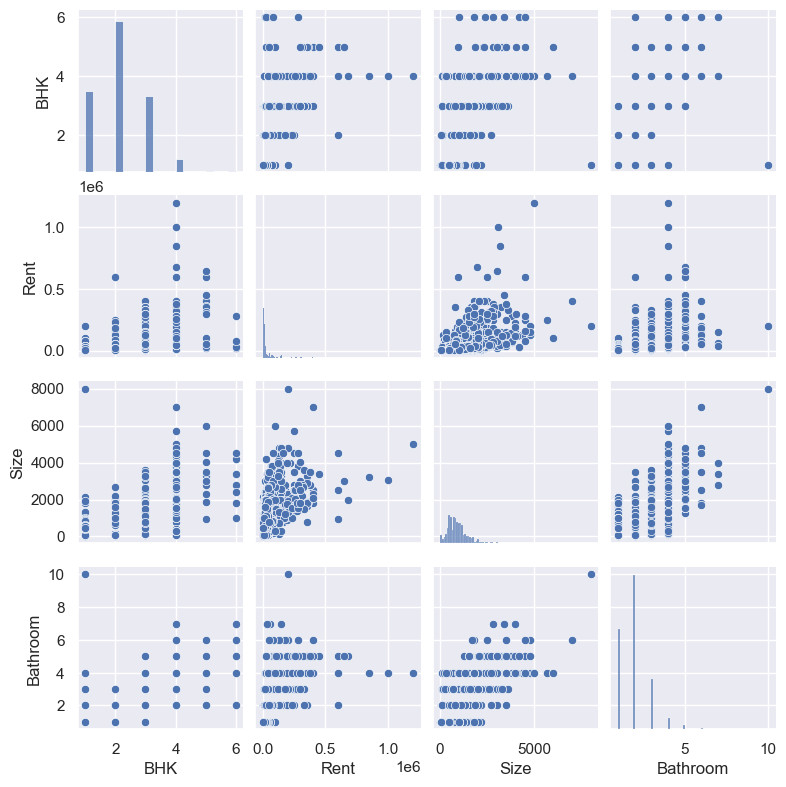

```python
sns.pairplot(train,height=2)
plt.show()
```

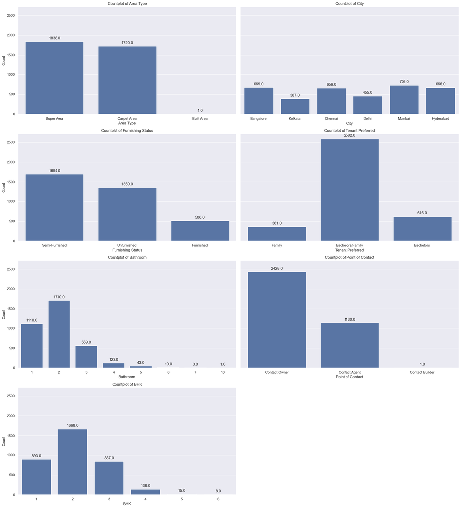

```python
count_cols = ['Area Type', 'City', 'Furnishing Status', 'Tenant Preferred', "Bathroom", 'Point of Contact', "BHK"]
fig, axs = plt.subplots(4, 2, figsize=(20, 22), sharey=True)
axs = axs.flatten()
for i, col in enumerate(count_cols):
    sns.countplot(x=col, data=train, ax=axs[i])
    axs[i].set_title(f'Countplot of {col}')
    axs[i].set_xlabel(col)
    axs[i].set_ylabel('Count')
    for p in axs[i].patches:
        axs[i].annotate(f'{p.get_height()}', (p.get_x() + p.get_width() / 2., p.get_height()),
                        ha='center', va='center', xytext=(0, 10), textcoords='offset points')
for i in range(len(count_cols), len(axs)):
    axs[i].axis('off')
plt.tight_layout()
plt.show()
```

Данные требуют предварительной обработки, Area Type, point of contact, BHK и Batroom можно слегка изменить, убрав категории в которых находится малое количество индивидов, плюс ещё признак этажа, с которым тоже надо чтото сделать. Дизбаланс в классах меня не сильно волнует, т.к регрессия

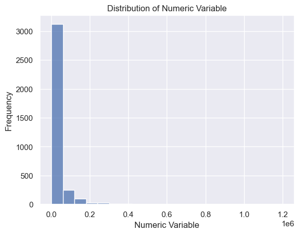

```python
sns.histplot(train['Rent'], bins=20)
plt.xlabel('Numeric Variable')
plt.ylabel('Frequency')
plt.title('Distribution of Numeric Variable')
plt.show()
```

Мне не очень нравится гистограмма стоимости аренды

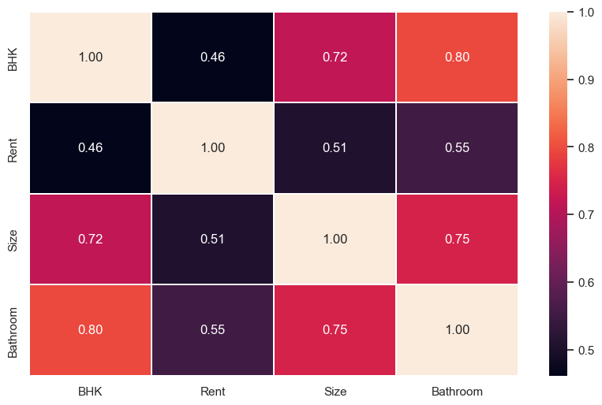

```python
plt.figure(figsize = (10,6))
sns.heatmap(train.select_dtypes(exclude = object).corr(), annot = True, fmt = ".2f", linewidths = 0.2)
plt.show()
```

По кореляциям в целом ожидаемо, хотя удивительно, что на стоимость аренды больше(хоть и чуть чуть) влияет количество ванных комнат, чем размер и количнство комнат в целом. Скорее всего действительно говорит о "люксовости дома"

Начинаю преобразовывать признаки

```python
house = house[~(house["Area Type"] == "Built Area")]
house = house[~(house["Point of Contact"] == "Contact Builder")]
house = house[~(house["Bathroom"] > 5)]
house = house[~(house["BHK"] > 5)]
house["Rent"] = np.log(house["Rent"])
```

В этот раз логарифмирую значения Rent(Оказало большое влияние на точность всех моделей). Но людей с большим количнством комнат и ванн все равно убрал т.к их всего 20 человек

```python
house["Floor House"] = house["Floor"].str.split(" ").str.get(0)
house["Floor Building"] = house["Floor"].str.split(" ").str.get(-1)
house.drop("Floor", axis=1, inplace=True)
house.loc[house["Floor House"] == "Ground", "Floor House"] = 0
house.loc[house["Floor Building"] == "Ground", "Floor Building"] = 0
house.loc[house["Floor House"] == "Lower", "Floor House"] = 0
house.loc[house["Floor House"] == "Upper", "Floor House"] = house.loc[house["Floor House"] == "Upper", "Floor Building"]
house["Floor House"] = house["Floor House"].astype(int)
house["Floor Building"] = house["Floor Building"].astype(int)
```

```python
len(house)
```

```
4723
```

Ещё раз разделим на трейн и тест уже переработанные данные

```python
train,test = train_test_split(house, random_state=1, test_size=0.25)
len(train),len(test)
```

```
(3542, 1181)
```

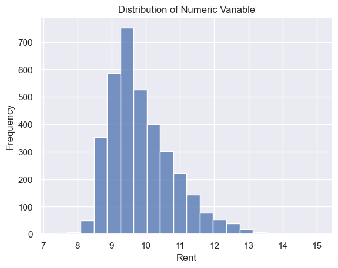

```python
sns.histplot(train['Rent'], bins=20)
plt.xlabel('Rent')
plt.ylabel('Frequency')
plt.title('Distribution of Numeric Variable')
plt.show()
```

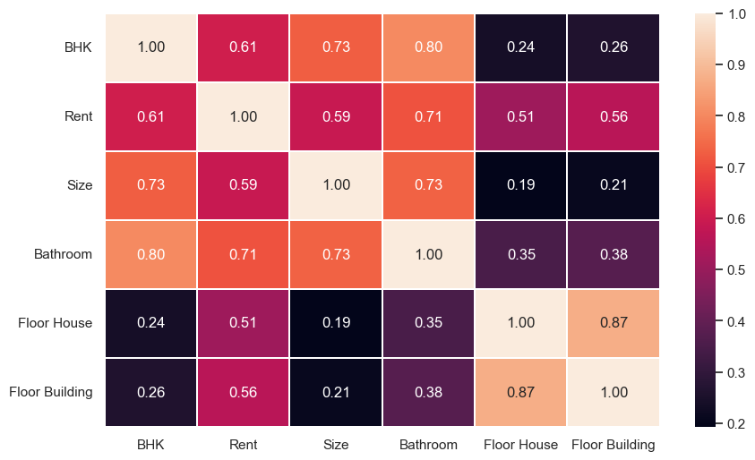

```python
plt.figure(figsize = (10,6))
sns.heatmap(train.select_dtypes(exclude = object).corr(), annot = True, fmt = ".2f", linewidths = 0.2)
plt.show()
```

Кореляции слегка поменялись. Признак количества ванных оказывает ещё больше влияния на стоимость аренды.

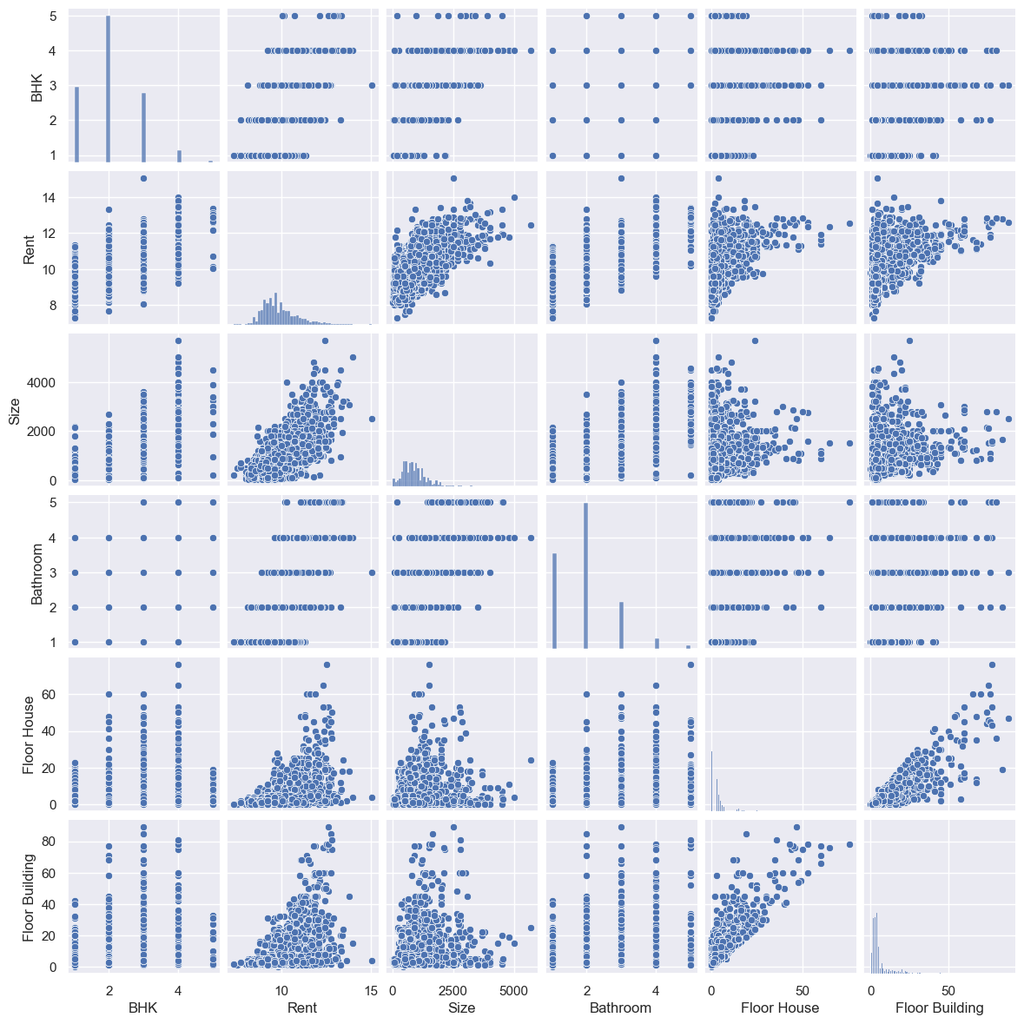

```python
sns.pairplot(train,height=2)
plt.show()
```

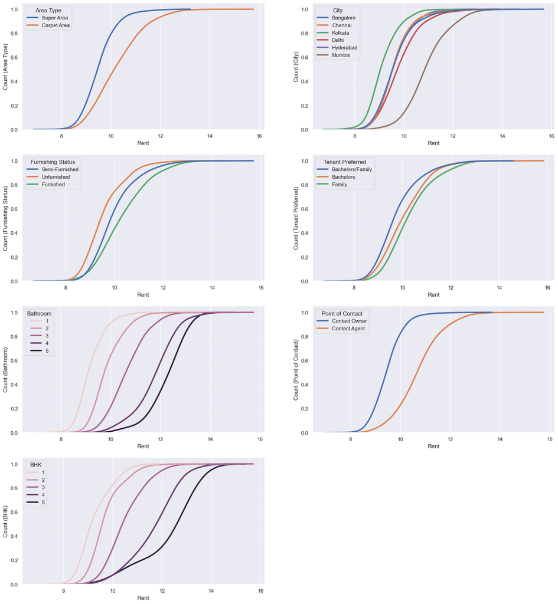

```python
count_cols = ['Area Type', 'City', 'Furnishing Status', 'Tenant Preferred', 'Bathroom', 'Point of Contact', 'BHK']
fig, axs = plt.subplots(4, 2, figsize=(20, 22))
for i, col in enumerate(count_cols):
    r_i = i // 2
    c_i = i % 2
    ax = axs[r_i][c_i]
    sns.kdeplot(data=train, x='Rent', hue=col,
                cumulative=True, ax=ax, warn_singular=False, linewidth=3, common_norm=False)
    ax.set(xlabel="Rent", ylabel=f"Count ({col})")
    sns.despine(ax=ax, left=True)
    ax.grid(axis='y', linewidth=0.2)

if len(count_cols) % 2 != 0:
    fig.delaxes(axs[-1, -1])

plt.show()
```

Карпент ареа и Супер ареа- это обозначения для вида домов?

Площадь ковра - это именно та часть вашего дома, которую можно покрыть ковром. Сюда не входит толщина внутренних стен, колонн и т. д. В квартире общие зоны, такие как холл, лифты, лестничные пролеты, игровая зона и т. д., не входят в площадь ковра. Фактическая площадь, которую вы получаете в пользование, - это площадь ковра. Это пространство, доступное для вашего распоряжения. Сюда входят кухня, спальня, гостиная и т. д. Площадь ковра составляет около 70 % от площади застройки.

Суперплощадь - эта площадь включает в себя фактическое измерение площади, указанное застройщиком. Она включает в себя все общие зоны, такие как коридоры, холлы, лифты и т.д. В некоторых случаях даже такие удобства, как клубный дом, бассейн, сад, детская игровая площадка, включаются в суперзастроенную площадь. Девелопер/застройщик взимает с вас плату на основе сверхзастроенной площади, также известной как "продаваемая площадь". Еще одна вещь, которую следует отметить, - суперзастроенная площадь зависит от площади квартиры, то есть если в рамках одного проекта есть 2 разных варианта, отличающихся по площади, 2 BHK и 3 BHK с разной площадью; она будет рассчитываться по площади каждой квартиры. Чаще всего площадь ковра - это фактическая полезная площадь для владельца дома и реальной жилой единицы. Большинство застройщиков при расчете базовой стоимости указывают площадь застройки, поэтому если удобств больше, то и площадь застройки выше.

Видно, самые догорие дома в Мумбаи. Карпет Ареа дороже, чем супер ареа. Агенства продают дома дороже, чем собственники. Furniture status и положение снимающиего не имеют особой разницы между собой. Количество комнат и ванн тоже заметно влияет на цену.

МОДЕЛИ

Для работы с нейронками, пришлось везде стандартизировать данные. Теперь стандартизирую нормально, коэффициентами от трейна

```python
dummy_df = pd.get_dummies(house,columns=['Area Type',	'City',	'Furnishing Status',	'Tenant Preferred',	'Point of Contact'],dtype=int)
scaler = StandardScaler()
numerical_cols = ['BHK','Rent', 'Size', 'Bathroom', 'Floor House', 'Floor Building']
# Преобразование булевых столбцов в числовой формат
train_d, test_d, = train_test_split(dummy_df, random_state=1, test_size=0.25)
#Теперь масштабирую тест на тех же коэффициентах, которыми стандартизировал трейн
scaler.fit(train_d)
train_d[numerical_cols] = scaler.fit_transform(train_d[numerical_cols])
test_d[numerical_cols] = scaler.transform(test_d[numerical_cols])
train_df, val_df = train_test_split(train_d, random_state=1, test_size=0.2)
X_train = train_df.drop('Rent', axis=1)
y_train = train_df['Rent']
X_val = val_df.drop('Rent', axis=1)
y_val = val_df['Rent']
X_test = test_d.drop('Rent', axis=1)
y_test = test_d['Rent']
```

```python
from sklearn.model_selection import  GridSearchCV
from sklearn.ensemble import RandomForestRegressor
from sklearn.metrics import mean_squared_error, r2_score
random.seed(1)
rf_model = RandomForestRegressor(random_state=1)
# Определение сетки параметров для поиска по сетке
param_grid = {
    'n_estimators': [ 150, 200,250],
    'max_depth': [ 15,20,30],
    'min_samples_split': [ 5,10,15],
    'min_samples_leaf': [1, 2, 4]
}
# Метрика для поиска MSE 'neg_' просто обозначение для metrics.mean_squared_error в документации почти все метрики касательно среднего с приписакой _neg
#'neg_mean_squared_error' просто MSE
grid_search = GridSearchCV(estimator=rf_model, param_grid=param_grid, scoring='neg_mean_squared_error', cv=5, n_jobs=-1)
# Обучение модели с использованием поиска по сетке
grid_search.fit(X_train, y_train)
print("Best Parameters:", grid_search.best_params_)
best_rf_model = grid_search.best_estimator_
# Оценка модели на Тренировочном наборе
y_train_pred = best_rf_model.predict(X_train)
mse_train_rf = mean_squared_error(y_train, y_train_pred)
r2_train_rf = r2_score(y_train, y_train_pred)
print(f'Train Mean Squared Error: {mse_train_rf:.4f}')
print(f'Train R-squared: {r2_train_rf:.4f}')
# Оценка модели на тестовом наборе
y_test_pred_rf = best_rf_model.predict(X_test)
mse_test_rf = mean_squared_error(y_test, y_test_pred_rf)
r2_test_rf = r2_score(y_test, y_test_pred_rf)
print(f'Test Mean Squared Error: {mse_test_rf:.4f}')
print(f'Test R-squared: {r2_test_rf:.4f}')
```

```
Best Parameters: {'max_depth': 20, 'min_samples_leaf': 4, 'min_samples_split': 10, 'n_estimators': 250}
Train Mean Squared Error: 0.0984
Train R-squared: 0.9002
Test Mean Squared Error: 0.1898
Test R-squared: 0.7989
```

Везде где пробегаюсь по сетке, делал это несколько раз, сдвигая границы. Оставил такие т.к из-за этого что я хотел оставить ее 3 на 3, периодически лучшие параметры работали на том, что из сетки пропадало после ее сдвига.

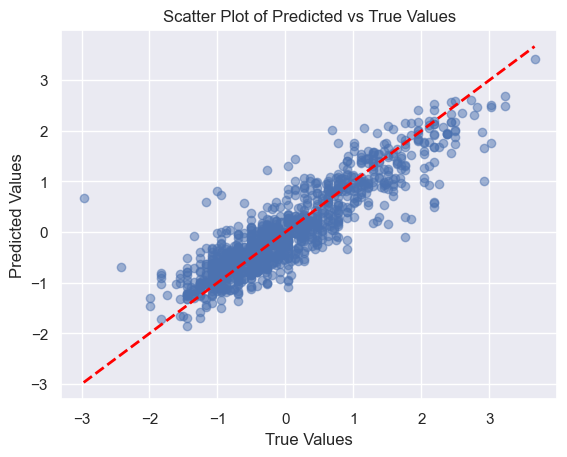

```python
plt.scatter(y_test, y_test_pred_rf, alpha=0.5)
plt.plot([min(y_test), max(y_test)], [min(y_test), max(y_test)], color='red', linestyle='--', linewidth=2)  # Добавляем диагональную линию
plt.title('Scatter Plot of Predicted vs True Values')
plt.xlabel('True Values')
plt.ylabel('Predicted Values')
plt.show()
```

После изменения графиков и логарифмирования стало полегче оценить модели. Я решил полностью убрать старые графики. В целом лес смотрится неплохо, но к сожалению дольше всех обучается(и сильнее всех переобучается). И есть несколько очень плохих точек.

BOOSTING

С бустингом хотел посмотреть на разные модели бустинга, чтобы потом на валидации выбрать лучшую из них

```python
from sklearn.ensemble import GradientBoostingRegressor
from xgboost import XGBRegressor
from sklearn.ensemble import AdaBoostRegressor

# Определение модели градиентного бустинга
gb_model = GradientBoostingRegressor(n_estimators=100, learning_rate=0.1, random_state=1)

# Обучение модели на обучающем наборе
gb_model.fit(X_train, y_train)

# Оценка модели на валидационном наборе
y_val_pred = gb_model.predict(X_val)
mse_val = mean_squared_error(y_val, y_val_pred)
r2_val = r2_score(y_val, y_val_pred)

print(f'Validation GradientBoosting Mean Squared Error: {mse_val:.4f}')
print(f'Validation GradientBoosting R-squared: {r2_val:.4f}')

#Модель адабустинга
adaboost_model = AdaBoostRegressor(n_estimators=100, learning_rate=0.1, random_state=1)

adaboost_model.fit(X_train, y_train)

y_val_pred = adaboost_model.predict(X_val)
mse_val = mean_squared_error(y_val, y_val_pred)
r2_val = r2_score(y_val, y_val_pred)

print(f'Validation AdaBoost Mean Squared Error: {mse_val:.4f}')
print(f'Validation AdaBoost R-squared: {r2_val:.4f}')
#Модель XGBregressor
xgb_model = XGBRegressor(n_estimators=100, learning_rate=0.1, random_state=1)

xgb_model.fit(X_train, y_train)

y_val_pred = xgb_model.predict(X_val)
mse_val = mean_squared_error(y_val, y_val_pred)
r2_val = r2_score(y_val, y_val_pred)

print(f'Validation XGBRegressor Mean Squared Error: {mse_val:.4f}')
print(f'Validation XGBRegressor R-squared: {r2_val:.4f}')
```

```
Validation GradientBoosting Mean Squared Error: 0.1941
Validation GradientBoosting R-squared: 0.8161
Validation AdaBoost Mean Squared Error: 0.3272
Validation AdaBoost R-squared: 0.6899
Validation XGBRegressor Mean Squared Error: 0.1987
Validation XGBRegressor R-squared: 0.8117
```

```python
# Определение сетки параметров для поиска по сетке
xgb_model = XGBRegressor(random_state=1)
param_grid = {
    'n_estimators': [ 50,100, 150],
    'learning_rate': [0.01, 0.1, 0.2],
    'max_depth': [2,3, 5,10],
    'min_samples_split': [2, 5, 10],
    'min_samples_leaf': [1, 2, 4]
}

# Инициализация объекта GridSearchCV
grid_search = GridSearchCV(estimator=xgb_model, param_grid=param_grid, scoring='neg_mean_squared_error', cv=5, n_jobs=-1)

# Обучение модели с использованием поиска по сетке
grid_search.fit(X_train, y_train)

# Вывод лучших параметров
print("Best Parameters:", grid_search.best_params_)

# Получение лучшей модели
best_gb_model = grid_search.best_estimator_

# Оценка модели на train
y_train_pred = best_gb_model.predict(X_train)
mse_train_boosting = mean_squared_error(y_train, y_train_pred)
r2_train_boosting = r2_score(y_train, y_train_pred)

print(f'train Mean Squared Error: {mse_train_boosting:.4f}')
print(f'train R-squared: {r2_train_boosting:.4f}')

# Оценка модели на тестовом наборе
y_test_pred = best_gb_model.predict(X_test)
mse_test_boosting = mean_squared_error(y_test, y_test_pred)
r2_test_boosting = r2_score(y_test, y_test_pred)

print(f'Test Mean Squared Error: {mse_test_boosting:.4f}')
print(f'Test R-squared: {r2_test_boosting:.4f}')
```

```
Best Parameters: {'learning_rate': 0.2, 'max_depth': 2, 'min_samples_leaf': 1, 'min_samples_split': 2, 'n_estimators': 150}
train Mean Squared Error: 0.1416
train R-squared: 0.8564
Test Mean Squared Error: 0.1799
Test R-squared: 0.8093
```

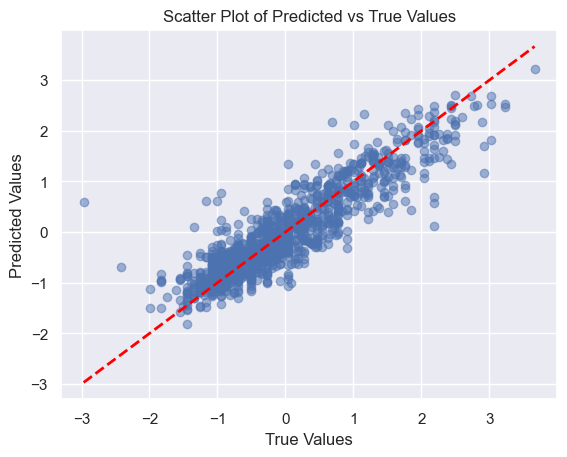

```python
plt.scatter(y_test, y_test_pred, alpha=0.5)
plt.plot([min(y_test), max(y_test)], [min(y_test), max(y_test)], color='red', linestyle='--', linewidth=2)  # Добавляем диагональную линию
plt.title('Scatter Plot of Predicted vs True Values')
plt.xlabel('True Values')
plt.ylabel('Predicted Values')
plt.show()
```

Сложно разглядеть разницу в кореляции предсказаний у бустинга и леса, но по ощущениям точки действительно чуть ближе друг к диагональной линии.

Добавил earlystoping, если валидация не меняется на протяжении 15 эпох. Изменил модель на более сложную с дропаутом в 0.25 процентов. Увеличил размер 1 слоя, добавил ещё 1 скрытый слой

```python
# Convert pandas DataFrames to PyTorch tensors
import torch.nn as nn
import torch.optim as optim
from torch.utils.data import DataLoader, TensorDataset
torch.manual_seed(1)
X_train_tensor = torch.tensor(X_train.values, dtype=torch.float32)
y_train_tensor = torch.tensor(y_train.values,dtype=torch.float32).view(-1, 1) # Reshape for a single output
X_val_tensor = torch.tensor(X_val.values, dtype=torch.float32)
y_val_tensor = torch.tensor(y_val.values, dtype=torch.float32).view(-
1, 1) # Reshape for a single output
# Create DataLoader for training and testing datasets
train_dataset = TensorDataset(X_train_tensor, y_train_tensor)
val_dataset = TensorDataset(X_val_tensor, y_val_tensor)
batch_size = 64
train_loader = DataLoader(train_dataset, batch_size=batch_size,
shuffle=True)
test_loader = DataLoader(val_dataset, batch_size=batch_size,
shuffle=False)
# Define a simple neural network model
class RegressionModel(nn.Module):
      def __init__(self, input_size):
        super(RegressionModel, self).__init__()
        self.fc1 = nn.Linear(input_size, 128)
        self.relu = nn.ReLU()
        self.dropout = nn.Dropout(0.25)  # Добавление слоя Dropout для регуляризации
        self.fc2 = nn.Linear(128, 64)
        self.fc3 = nn.Linear(64, 1)

      def forward(self, x):
        x = self.fc1(x)
        x = self.relu(x)
        x = self.dropout(x)
        x = self.fc2(x)
        x = self.relu(x)
        x = self.dropout(x)
        x = self.fc3(x)
        return x

# Instantiate the model
input_size = X_train.shape[1]
model = RegressionModel(input_size)

# Define loss function and optimizer
criterion = nn.MSELoss()
optimizer = optim.Adam(model.parameters(), lr=0.001)
early_stopping_patience = 15  # Number of epochs to wait for improvement
best_val_loss = float('inf')
current_patience = 0
# Training loop
num_epochs = 100
for epoch in range(num_epochs):
    model.train()
    for batch_X, batch_y in train_loader:
        optimizer.zero_grad()
        outputs = model(batch_X)
        loss = criterion(outputs, batch_y)
        loss.backward()
        optimizer.step()

    # Evaluate on training set
    model.eval()
    with torch.no_grad():
        train_predictions = model(X_train_tensor)
        train_loss = criterion(train_predictions, y_train_tensor)
        r2_trainnn = r2_score(y_train_tensor.numpy(),train_predictions.numpy())

    # Evaluate on val set
    with torch.no_grad():
        val_predictions = model(X_val_tensor)
        val_loss = criterion(val_predictions, y_val_tensor)
        r2_test = r2_score(y_val_tensor.numpy(),val_predictions.numpy())

    if val_loss < best_val_loss:
        best_val_loss = val_loss
        current_patience = 0
    else:
        current_patience += 1
        if current_patience >= early_stopping_patience:
            print(f'Early stopping after {epoch+1} epochs')
            break
    # Print training and testing metrics for every epoch
    print(f'Epoch [{epoch+1}/{num_epochs}], Train Loss: {train_loss.item():.4f}, Val Loss: {val_loss.item():.4f}, R-squared: {r2_test:.4f}')

X_test_tensor = torch.tensor(X_test.values, dtype=torch.float32)
y_test_tensor = torch.tensor(y_test.values, dtype=torch.float32).view(-1, 1)

# Final evaluation on the test set
model.eval()
with torch.no_grad():
    final_test_predictions = model(X_test_tensor)
    final_test_loss = criterion(final_test_predictions, y_test_tensor)
    final_r2_test = r2_score(y_test_tensor.numpy(), final_test_predictions.numpy())

print(f'Final Test Loss: {final_test_loss.item():.4f}, Final R-squared: {final_r2_test:.4f}')
```

```
Epoch [1/100], Train Loss: 0.2384, Val Loss: 0.2632, R-squared: 0.7506
Epoch [2/100], Train Loss: 0.1902, Val Loss: 0.2236, R-squared: 0.7882
Epoch [3/100], Train Loss: 0.1776, Val Loss: 0.2151, R-squared: 0.7962
Epoch [4/100], Train Loss: 0.1710, Val Loss: 0.2036, R-squared: 0.8071
Epoch [5/100], Train Loss: 0.1686, Val Loss: 0.2044, R-squared: 0.8063
Epoch [6/100], Train Loss: 0.1663, Val Loss: 0.2037, R-squared: 0.8070
Epoch [7/100], Train Loss: 0.1635, Val Loss: 0.1956, R-squared: 0.8146
Epoch [8/100], Train Loss: 0.1617, Val Loss: 0.1973, R-squared: 0.8130
Epoch [9/100], Train Loss: 0.1618, Val Loss: 0.1980, R-squared: 0.8123
Epoch [10/100], Train Loss: 0.1643, Val Loss: 0.1989, R-squared: 0.8115
Epoch [11/100], Train Loss: 0.1596, Val Loss: 0.1955, R-squared: 0.8148
Epoch [12/100], Train Loss: 0.1559, Val Loss: 0.1920, R-squared: 0.8181
Epoch [13/100], Train Loss: 0.1564, Val Loss: 0.1925, R-squared: 0.8176
Epoch [14/100], Train Loss: 0.1554, Val Loss: 0.1903, R-squared: 0.8196
Epoch [15/100], Train Loss: 0.1543, Val Loss: 0.1934, R-squared: 0.8167
Epoch [16/100], Train Loss: 0.1534, Val Loss: 0.1947, R-squared: 0.8155
Epoch [17/100], Train Loss: 0.1548, Val Loss: 0.1933, R-squared: 0.8169
Epoch [18/100], Train Loss: 0.1527, Val Loss: 0.1916, R-squared: 0.8185
Epoch [19/100], Train Loss: 0.1508, Val Loss: 0.1900, R-squared: 0.8199
Epoch [20/100], Train Loss: 0.1527, Val Loss: 0.1934, R-squared: 0.8167
Epoch [21/100], Train Loss: 0.1510, Val Loss: 0.1955, R-squared: 0.8147
Epoch [22/100], Train Loss: 0.1471, Val Loss: 0.1899, R-squared: 0.8200
Epoch [23/100], Train Loss: 0.1519, Val Loss: 0.2004, R-squared: 0.8101
Epoch [24/100], Train Loss: 0.1522, Val Loss: 0.1936, R-squared: 0.8165
Epoch [25/100], Train Loss: 0.1457, Val Loss: 0.1877, R-squared: 0.8221
Epoch [26/100], Train Loss: 0.1484, Val Loss: 0.1961, R-squared: 0.8141
Epoch [27/100], Train Loss: 0.1444, Val Loss: 0.1888, R-squared: 0.8211
Epoch [28/100], Train Loss: 0.1455, Val Loss: 0.1946, R-squared: 0.8156
Epoch [29/100], Train Loss: 0.1429, Val Loss: 0.1922, R-squared: 0.8178
Epoch [30/100], Train Loss: 0.1427, Val Loss: 0.1906, R-squared: 0.8194
Epoch [31/100], Train Loss: 0.1423, Val Loss: 0.1912, R-squared: 0.8188
Epoch [32/100], Train Loss: 0.1432, Val Loss: 0.1890, R-squared: 0.8209
Epoch [33/100], Train Loss: 0.1409, Val Loss: 0.1869, R-squared: 0.8228
Epoch [34/100], Train Loss: 0.1431, Val Loss: 0.1903, R-squared: 0.8196
Epoch [35/100], Train Loss: 0.1385, Val Loss: 0.1885, R-squared: 0.8214
Epoch [36/100], Train Loss: 0.1416, Val Loss: 0.1931, R-squared: 0.8170
Epoch [37/100], Train Loss: 0.1383, Val Loss: 0.1897, R-squared: 0.8203
Epoch [38/100], Train Loss: 0.1361, Val Loss: 0.1878, R-squared: 0.8221
Epoch [39/100], Train Loss: 0.1398, Val Loss: 0.1898, R-squared: 0.8201
Epoch [40/100], Train Loss: 0.1378, Val Loss: 0.1900, R-squared: 0.8200
```

[output cut: 9 more lines]

```
Epoch [50/100], Train Loss: 0.1365, Val Loss: 0.1873, R-squared: 0.8225
Epoch [51/100], Train Loss: 0.1322, Val Loss: 0.1911, R-squared: 0.8189
Epoch [52/100], Train Loss: 0.1302, Val Loss: 0.1894, R-squared: 0.8206
Epoch [53/100], Train Loss: 0.1314, Val Loss: 0.1889, R-squared: 0.8210
Epoch [54/100], Train Loss: 0.1301, Val Loss: 0.1886, R-squared: 0.8213
Epoch [55/100], Train Loss: 0.1304, Val Loss: 0.1907, R-squared: 0.8193
Epoch [56/100], Train Loss: 0.1304, Val Loss: 0.1901, R-squared: 0.8198
Epoch [57/100], Train Loss: 0.1280, Val Loss: 0.1876, R-squared: 0.8222
Epoch [58/100], Train Loss: 0.1296, Val Loss: 0.1858, R-squared: 0.8239
Epoch [59/100], Train Loss: 0.1282, Val Loss: 0.1896, R-squared: 0.8204
Epoch [60/100], Train Loss: 0.1284, Val Loss: 0.1917, R-squared: 0.8183
Epoch [61/100], Train Loss: 0.1296, Val Loss: 0.1956, R-squared: 0.8146
Epoch [62/100], Train Loss: 0.1257, Val Loss: 0.1865, R-squared: 0.8233
Early stopping after 63 epochs
Final Test Loss: 0.1777, Final R-squared: 0.8117
```

Путем пробы разных моделей, я смог добится того, чтобы лучшие показатели были у нейронной сети. Не то, чтобы это звучало справедливо, потому что для леса я по сути только пробежался по сетке, как и для бустинга(пусть и выбрав 1 из 3 моделей). Возможно, потратив на них столько же усилий, я бы добился лучших показателей, но учитывая что на обучения леса по сетке 3 на 3 тратится в 15 раз больше времени, чем на НН, думаю что все честно.

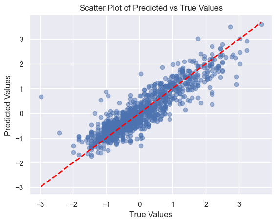

```python
plt.scatter(y_test, final_test_predictions, alpha=0.5)
plt.plot([min(y_test), max(y_test)], [min(y_test), max(y_test)], color='red', linestyle='--', linewidth=2)  # Добавляем диагональную линию
plt.title('Scatter Plot of Predicted vs True Values')
plt.xlabel('True Values')
plt.ylabel('Predicted Values')
plt.show()
```

Скатер плот как и у прошлый моделей хороший как мне кажется(возмонжо даже точек, которые дальше от диагонали дальше поменьше), но огорчает, что ни одна модель не смогла как то справится с самой левой точкой.

```python
test_data = {
    'RFmse': [mse_test_rf, mse_train_rf],
    'RFr2': [r2_test_rf, r2_train_rf],
    'BoostingMSE': [mse_test_boosting, mse_train_boosting],
    'Boostingr2': [r2_test_boosting, r2_train_boosting],
    'NNmse': [final_test_loss.item(), train_loss.item()],
    'NNr2': [final_r2_test, r2_trainnn]
}

# Создание DataFrame
accuracy_df = pd.DataFrame(test_data, index=['test', 'train'])

accuracy_df
```

|  | RFmse | RFr2 | BoostingMSE | Boostingr2 | NNmse | NNr2 |
| --- | --- | --- | --- | --- | --- | --- |
| test | 0.189805 | 0.798855 | 0.179903 | 0.809349 | 0.177675 | 0.811709 |
| train | 0.098388 | 0.900226 | 0.141609 | 0.856397 | 0.125954 | 0.872272 |

C изменением графика стало возможно полегче как-то смотреть именно на качество предсказания. Я ожидал, что лес сильнее всех переобучится, хоть он и был ограничен сеткой. У бустинга и леса была долгая борьба за первенство по метрикам, но путем моих махинаций с моделью, НН все таки получил значения лучше, чем у бустинга(пусть и чуть-чуть).

[figure not shown]

```python
plt.figure(figsize=(18, 5))
plt.subplot(1, 3, 1)
plt.scatter(y_test, y_test_pred_rf, alpha=0.5)
plt.plot([min(y_test), max(y_test)], [min(y_test), max(y_test)], color='red', linestyle='--', linewidth=2)
plt.title('Random Forest Predictions')
plt.xlabel('True Values')
plt.ylabel('Predicted Values')


plt.subplot(1, 3, 2)
plt.scatter(y_test, y_test_pred, alpha=0.5)
plt.plot([min(y_test), max(y_test)], [min(y_test), max(y_test)], color='red', linestyle='--', linewidth=2)
plt.title('Boosting Predictions')
plt.xlabel('True Values')
plt.ylabel('Predicted Values')

plt.subplot(1, 3, 3)
plt.scatter(y_test, final_test_predictions, alpha=0.5)
plt.plot([min(y_test), max(y_test)], [min(y_test), max(y_test)], color='red', linestyle='--', linewidth=2)
plt.title('NN Model Predictions')
plt.xlabel('True Values')
plt.ylabel('Predicted Values')

plt.tight_layout()
plt.show()
```

Смотря на все графики рядом, видно, что лес действительно чуть-чуть потолще, чем две другие модели. А НН как-то более компактно ошибается ближе к верхней части диагонали(лес и бустинг в основном занижают предсказанные значения)